# FAST-BERT MULTICLASS SENTIMENT CLASSIFICATION

**1. Load Data & Libraries**  
- Prepare Data  
**2. Fine-Tune BERT**  
- GPU Checks and Configurations  
- Set Paths & Model Configurations  
- Create DataBunch Object  
- Create Learner Object  
- Fit Learner  
**3. Performance**  
- Predictions  
- Does the Model Generalize?  
**4. Error Analysis**  
- Performance on the Eyeball Validation Set  
- Classifier Errors  
- How Confident were Mistakes?  
**5. Correct Labels using Predictions**  
- How many incorrect labels were corrected?  
- Class Distributions after Correction  
**6. Predictions on Corrected Dataset**  
- Final Results - Test Set  
**7. Calibration**  
- Diagnosing Miscalibration  
- Evaluation Metrics  
- Uncalibrated Results  
- Temperature Scaling  
- Dirichlet Scaling  
- Isotronic Binning  
- Comparing Methods  
**8. Conclusion**

# Load Libraries and Data

```python
%load_ext autoreload
%autoreload 2
```

```python
# Load libraries and configure notebook settings
%matplotlib inline
from libraries_bert import *
import datetime

run_start_time = datetime.datetime.today().strftime('%Y-%m-%d_%H-%M-%S')
np.random.seed(0)

import warnings
warnings.filterwarnings('ignore')
```

```python
# The same Train, Validation and Test sets were used across notebooks
# for reliable comparison of performances.
X_train = pd.read_json('data/train.json', orient='columns')
X_val = pd.read_json('data/val.json', orient='columns')
X_test = pd.read_json('data/test.json', orient='columns')
X_eyeval = pd.read_json('data/eyeball_val_set2.json', orient='columns')

y_train = X_train.sentiment.to_numpy().flatten()
y_val = X_val.sentiment.to_numpy().flatten()
y_test = X_test.sentiment.to_numpy().flatten()
y_eyeval = X_eyeval.sentiment.to_numpy().flatten()

len(X_train), len(X_val), len(X_test), len(X_eyeval)
```

```
(143095, 11130, 4770, 501)
```

## Prepare Data

```python
def prepare_datasets(df):
    data = df[['combined', 'sentiment']].copy()
    # rename columns
    data.rename(columns={'combined':'text', 'sentiment':'label'}, inplace=True)
    # replace integers with text labels
    data['label'] = data['label'].map({0: 'neg', 1: 'pos', 2: 'mixed'})
    return data

train = prepare_datasets(X_train)
val = prepare_datasets(X_val)
test = prepare_datasets(X_test)
eyeball_val = prepare_datasets(X_eyeval)

train.head()
```

|  | text | label |
| --- | --- | --- |
| 95213 | Hein and his team is just great service good f... | pos |
| 127356 | Lovely kids play area Food and service was good | pos |
| 12130 | Great food great people | pos |
| 20350 | Asher. Great food + service | pos |
| 143333 | Great food. Great service. Highly recommended... | mixed |

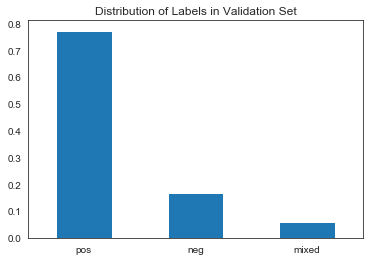

```python
# Ensure label distribution is correctly stratified in
# validation set
val.label.value_counts(normalize=True).plot(kind='bar')
plt.title('Distribution of Labels in Validation Set')
plt.xticks(rotation=0);
```

```python
# save labels to csv file
labels = ['neg', 'pos', 'mixed']

LABEL_PATH = Path('C:/Users/Danyal/socialplaces/dsc-4-final-project-online-ds-ft-112618/fast_bert/labels/')

with open(LABEL_PATH/'labels.csv', 'w') as csvfile:
    for label in labels:
        csvfile.write(label + '\n')

# save train, val, test sets to csv
def create_csv(df, filename):
    df.to_csv(filename)

DATA_PATH = Path('C:/Users/Danyal/socialplaces/dsc-4-final-project-online-ds-ft-112618/fast_bert/data/')

create_csv(train, DATA_PATH/'train.csv')
create_csv(val, DATA_PATH/'val.csv')
create_csv(test, DATA_PATH/'test.csv')

# unzip bert base uncased weights and extract into models folder
# in appropriate directory
BERT_PRETRAINED_PATH = Path('C:/Users/Danyal/socialplaces/dsc-4-final-project-online-ds-ft-112618/bert_models/pretrained_uncased/')
#with zipfile.ZipFile('uncased_L-12_H-768_A-12.zip', 'r') as zip_ref:
#    zip_ref.extractall(BERT_PRETRAINED_PATH)
```

# Fine-Tune Bert

The fast-bert library was used to fine-tune a [pytorch transfomer](https://github.com/huggingface/transformers) bert language model. Fast-bert is a Fast-AI inspired high level wrapper for the transformer architectures that works particularly well for fine-tuning these models to downstream classification tasks.

Return to Index

## GPU Checks and Configurations

```python
# empty cache
torch.cuda.empty_cache()

#torch.ones((48*2**18)).cuda().contiguous() # check vectors can fit in gpu memory

# ensure gpu is available and enabled; check cuda version
torch.cuda.is_available(), torch.backends.cudnn.enabled, torch.version.cuda
```

```
(True, True, '10.0')
```

```python
# set cuda device
device_cuda = torch.device("cuda")
```

## Set Paths & Model Configurations

```python
# path for model artifacts to be stored
MODEL_PATH = Path('C:/Users/Danyal/socialplaces/dsc-4-final-project-online-ds-ft-112618/fast_bert/models/')

LOG_PATH = Path('C:/Users/Danyal/socialplaces/dsc-4-final-project-online-ds-ft-112618/fast_bert/logs/')
OUTPUT_DIR = Path('C:/Users/Danyal/socialplaces/dsc-4-final-project-online-ds-ft-112618/fast_bert/models/output/')

# location for the pretrained BERT models
BERT_PRETRAINED_PATH = Path('C:/Users/Danyal/socialplaces/dsc-4-final-project-online-ds-ft-112618/bert_models/pretrained_uncased/uncased_L-12_H-768_A-12/')


# Box is a nice wrapper to create an object from a json dict
args = Box({
    "run_text": "multiclass sentiment with freezable layers",
    "task_name": 'sentiment_classification',
    "model_type": 'bert',
    "model_name": 'bert-base-uncased',
    "do_lower_case": True,
    "max_grad_norm": 1.0,
    "train_batch_size": 8,
    "eval_batch_size": 16,
    "max_seq_length": 256,
    "learning_rate": 4e-5,
    "warmup_proportion": 0.002,
    "local_rank": -1,
    "gradient_accumulation_steps": 8,
    "fp16": True,
    "fp16_opt_level": "O2",
    "eval_all_checkpoints": True,
    "overwrite_output_dir": True,
    "warmup_steps": 500,
    "logging_steps": 50,
    "overwrite_cache": False,
    "seed": 45
})

logfile = str(LOG_PATH/'log-{}-{}.txt'.format(run_start_time, args["run_text"]))

logging.basicConfig(
    level=logging.INFO,
    format='%(asctime)s - %(levelname)s - %(name)s -   %(message)s',
    datefmt='%m/%d/%Y %H:%M:%S',
    handlers=[
        logging.FileHandler(logfile),
        logging.StreamHandler(sys.stdout)
    ])

logger = logging.getLogger()

logger.info(args)
```

[output not shown]

## Create DataBunch Object

```python
# The databunch object takes training, validation and test csv files and
# converts the data into internal representation for BERT.
# The object also instantiates the correct data-loaders based on device profile
# and batch_size and max_sequence_length.

databunch = BertDataBunch(DATA_PATH,
                          LABEL_PATH,
                          tokenizer=args.model_name,
                          train_file='train.csv',
                          val_file='val.csv',
                          test_data='test.csv',
                          text_col="text",
                          label_file='labels.csv',
                          label_col='label',
                          multi_label=False,
                          batch_size_per_gpu=args['train_batch_size'],
                          max_seq_length=args['max_seq_length'],
                          multi_gpu=True)
```

```
10/17/2019 16:43:06 - INFO - transformers.tokenization_utils -   loading file https://s3.amazonaws.com/models.huggingface.co/bert/bert-base-uncased-vocab.txt from cache at C:\Users\Danyal\.cache\torch\transformers\26bc1ad6c0ac742e9b52263248f6d0f00068293b33709fae12320c0e35ccfbbb.542ce4285a40d23a55952…
10/17/2019 16:43:06 - INFO - root -   Loading features from cached file C:\Users\Danyal\socialplaces\dsc-4-final-project-online-ds-ft-112618\fast_bert\data\cache\cached_bert_train_multi_class_256
10/17/2019 16:43:12 - INFO - root -   Loading features from cached file C:\Users\Danyal\socialplaces\dsc-4-final-project-online-ds-ft-112618\fast_bert\data\cache\cached_bert_dev_multi_class_256
10/17/2019 16:43:13 - INFO - root -   Loading features from cached file C:\Users\Danyal\socialplaces\dsc-4-final-project-online-ds-ft-112618\fast_bert\data\cache\cached_bert_test_multi_class_256
```

```python
# Ensure the max sequence length and batch sizes are set
# correctly
databunch.max_seq_length, databunch.batch_size_per_gpu
```

```
(256, 8)
```

## Create Learner Object

```python
logger = logging.getLogger()
device_cuda = torch.device("cuda")

metrics = []
metrics.append({'name': 'accuracy', 'function': accuracy})

# Create learner object
learner = BertLearner.from_pretrained_model(databunch,
                                            pretrained_path=args.model_name,
                                            metrics=metrics,
                                            device=device_cuda,
                                            logger=logger,
                                            fp16_opt_level=args.fp16_opt_level,
                                            output_dir=OUTPUT_DIR,
                                            finetuned_wgts_path=None,
                                            warmup_steps=args.warmup_steps,
                                            grad_accumulation_steps=args.gradient_accumulation_steps,
                                            multi_gpu=True,
                                            is_fp16=True,
                                            multi_label=False,
                                            logging_steps=50)
```

[output not shown]

## Fit Learner

```python
# gradient accumulation allows larger batch sizes to fit into memory.
# Grad accumulation = 8, batch size = 8, total batch size = 64.

learner.fit(epochs=1,
            lr=4e-5,
            validate=True, # Evaluate the model after each epoch
            schedule_type="warmup_cosine",
            optimizer_type="adamw")
```

[output not shown]

```
10/17/2019 16:46:39 - INFO - root -   Running evaluation
10/17/2019 16:46:39 - INFO - root -     Num examples = 8973
10/17/2019 16:46:39 - INFO - root -     Batch size = 16
```

100.00% [561/561 01:53<00:00]

```
10/17/2019 16:48:33 - INFO - root -   eval_loss after step 50: 0.7450057793003565:
10/17/2019 16:48:33 - INFO - root -   eval_accuracy after step 50: 0.7716482781678369:
10/17/2019 16:48:33 - INFO - root -   lr after step 50: 4.000000000000001e-06
10/17/2019 16:48:33 - INFO - root -   train_loss after step 50: 0.89661865234375
10/17/2019 16:51:35 - INFO - root -   Running evaluation
10/17/2019 16:51:35 - INFO - root -     Num examples = 8973
10/17/2019 16:51:35 - INFO - root -     Batch size = 16
```

100.00% [561/561 01:54<00:00]

```
10/17/2019 16:53:30 - INFO - root -   eval_loss after step 100: 0.3342188326857732:
10/17/2019 16:53:30 - INFO - root -   eval_accuracy after step 100: 0.9174189234369776:
10/17/2019 16:53:30 - INFO - root -   lr after step 100: 8.000000000000001e-06
10/17/2019 16:53:30 - INFO - root -   train_loss after step 100: 0.5468498229980469
10/17/2019 16:56:33 - INFO - root -   Running evaluation
10/17/2019 16:56:33 - INFO - root -     Num examples = 8973
10/17/2019 16:56:33 - INFO - root -     Batch size = 16
```

100.00% [561/561 01:54<00:00]

```
10/17/2019 16:58:28 - INFO - root -   eval_loss after step 150: 0.22500147964015152:
10/17/2019 16:58:28 - INFO - root -   eval_accuracy after step 150: 0.9284520227348713:
10/17/2019 16:58:28 - INFO - root -   lr after step 150: 1.2e-05
10/17/2019 16:58:28 - INFO - root -   train_loss after step 150: 0.28356109619140624
Gradient overflow.  Skipping step, loss scaler 0 reducing loss scale to 32768.0
10/17/2019 17:01:30 - INFO - root -   Running evaluation
10/17/2019 17:01:30 - INFO - root -     Num examples = 8973
10/17/2019 17:01:30 - INFO - root -     Batch size = 16
```

100.00% [561/561 01:54<00:00]

```
10/17/2019 17:03:24 - INFO - root -   eval_loss after step 200: 0.137972269041228:
10/17/2019 17:03:24 - INFO - root -   eval_accuracy after step 200: 0.9566477209405996:
10/17/2019 17:03:24 - INFO - root -   lr after step 200: 1.6000000000000003e-05
10/17/2019 17:03:24 - INFO - root -   train_loss after step 200: 0.17820159912109376
10/17/2019 17:06:26 - INFO - root -   Running evaluation
10/17/2019 17:06:26 - INFO - root -     Num examples = 8973
10/17/2019 17:06:26 - INFO - root -     Batch size = 16
```

100.00% [561/561 01:54<00:00]

```
10/17/2019 17:08:21 - INFO - root -   eval_loss after step 250: 0.11918874050419173:
10/17/2019 17:08:21 - INFO - root -   eval_accuracy after step 250: 0.9613284297336454:
10/17/2019 17:08:21 - INFO - root -   lr after step 250: 2e-05
10/17/2019 17:08:21 - INFO - root -   train_loss after step 250: 0.14478786468505858
10/17/2019 17:11:24 - INFO - root -   Running evaluation
10/17/2019 17:11:24 - INFO - root -     Num examples = 8973
10/17/2019 17:11:24 - INFO - root -     Batch size = 16
```

100.00% [561/561 01:55<00:00]

```
10/17/2019 17:13:19 - INFO - root -   eval_loss after step 300: 0.13176280546953334:
10/17/2019 17:13:19 - INFO - root -   eval_accuracy after step 300: 0.95698205728296:
10/17/2019 17:13:19 - INFO - root -   lr after step 300: 2.4e-05
10/17/2019 17:13:19 - INFO - root -   train_loss after step 300: 0.1532316780090332
10/17/2019 17:16:20 - INFO - root -   Running evaluation
10/17/2019 17:16:20 - INFO - root -     Num examples = 8973
10/17/2019 17:16:20 - INFO - root -     Batch size = 16
```

100.00% [561/561 01:54<00:00]

```
10/17/2019 17:18:15 - INFO - root -   eval_loss after step 350: 0.11374922019700102:
10/17/2019 17:18:15 - INFO - root -   eval_accuracy after step 350: 0.9630001114454475:
10/17/2019 17:18:15 - INFO - root -   lr after step 350: 2.8e-05
10/17/2019 17:18:15 - INFO - root -   train_loss after step 350: 0.1266941738128662
10/17/2019 17:21:17 - INFO - root -   Running evaluation
10/17/2019 17:21:17 - INFO - root -     Num examples = 8973
10/17/2019 17:21:17 - INFO - root -     Batch size = 16
```

100.00% [561/561 01:54<00:00]

```
10/17/2019 17:23:11 - INFO - root -   eval_loss after step 400: 0.10914998046004623:
10/17/2019 17:23:11 - INFO - root -   eval_accuracy after step 400: 0.9644489022623426:
10/17/2019 17:23:11 - INFO - root -   lr after step 400: 3.2000000000000005e-05
10/17/2019 17:23:11 - INFO - root -   train_loss after step 400: 0.11116045475006103
10/17/2019 17:26:14 - INFO - root -   Running evaluation
10/17/2019 17:26:14 - INFO - root -     Num examples = 8973
10/17/2019 17:26:14 - INFO - root -     Batch size = 16
```

100.00% [561/561 01:55<00:00]

```
10/17/2019 17:28:10 - INFO - root -   eval_loss after step 450: 0.11300869634019713:
10/17/2019 17:28:10 - INFO - root -   eval_accuracy after step 450: 0.9618856569709128:
10/17/2019 17:28:10 - INFO - root -   lr after step 450: 3.6e-05
10/17/2019 17:28:10 - INFO - root -   train_loss after step 450: 0.1225838851928711
10/17/2019 17:31:12 - INFO - root -   Running evaluation
10/17/2019 17:31:12 - INFO - root -     Num examples = 8973
10/17/2019 17:31:12 - INFO - root -     Batch size = 16
```

100.00% [561/561 01:55<00:00]

```
10/17/2019 17:33:07 - INFO - root -   eval_loss after step 500: 0.13537832929913798:
10/17/2019 17:33:07 - INFO - root -   eval_accuracy after step 500: 0.9550874846762509:
10/17/2019 17:33:07 - INFO - root -   lr after step 500: 4e-05
10/17/2019 17:33:07 - INFO - root -   train_loss after step 500: 0.14910144805908204
Gradient overflow.  Skipping step, loss scaler 0 reducing loss scale to 32768.0
10/17/2019 17:36:09 - INFO - root -   Running evaluation
10/17/2019 17:36:09 - INFO - root -     Num examples = 8973
10/17/2019 17:36:09 - INFO - root -     Batch size = 16
```

100.00% [561/561 01:54<00:00]

```
10/17/2019 17:38:03 - INFO - root -   eval_loss after step 550: 0.11692436238661169:
10/17/2019 17:38:03 - INFO - root -   eval_accuracy after step 550: 0.9618856569709128:
10/17/2019 17:38:03 - INFO - root -   lr after step 550: 3.990405437753535e-05
10/17/2019 17:38:03 - INFO - root -   train_loss after step 550: 0.13700152158737183
10/17/2019 17:41:04 - INFO - root -   Running evaluation
10/17/2019 17:41:04 - INFO - root -     Num examples = 8973
10/17/2019 17:41:04 - INFO - root -     Batch size = 16
```

100.00% [561/561 01:54<00:00]

```
10/17/2019 17:42:59 - INFO - root -   eval_loss after step 600: 0.10806674583285462:
10/17/2019 17:42:59 - INFO - root -   eval_accuracy after step 600: 0.9624428842081801:
10/17/2019 17:42:59 - INFO - root -   lr after step 600: 3.961713806638841e-05
10/17/2019 17:42:59 - INFO - root -   train_loss after step 600: 0.11242183923721313
10/17/2019 17:46:02 - INFO - root -   Running evaluation
10/17/2019 17:46:02 - INFO - root -     Num examples = 8973
10/17/2019 17:46:02 - INFO - root -     Batch size = 16
```

100.00% [561/561 01:55<00:00]

```
10/17/2019 17:47:58 - INFO - root -   eval_loss after step 650: 0.11312112451237154:
10/17/2019 17:47:58 - INFO - root -   eval_accuracy after step 650: 0.963111556892901:
10/17/2019 17:47:58 - INFO - root -   lr after step 650: 3.9142003902965996e-05
10/17/2019 17:47:58 - INFO - root -   train_loss after step 650: 0.1167381763458252
10/17/2019 17:51:02 - INFO - root -   Running evaluation
10/17/2019 17:51:02 - INFO - root -     Num examples = 8973
10/17/2019 17:51:02 - INFO - root -     Batch size = 16
```

100.00% [561/561 01:55<00:00]

```
10/17/2019 17:52:57 - INFO - root -   eval_loss after step 700: 0.11956552515692889:
10/17/2019 17:52:57 - INFO - root -   eval_accuracy after step 700: 0.96500612949961:
10/17/2019 17:52:57 - INFO - root -   lr after step 700: 3.8483210591574504e-05
10/17/2019 17:52:57 - INFO - root -   train_loss after step 700: 0.1253969383239746
10/17/2019 17:55:59 - INFO - root -   Running evaluation
10/17/2019 17:55:59 - INFO - root -     Num examples = 8973
10/17/2019 17:55:59 - INFO - root -     Batch size = 16
```

100.00% [561/561 01:54<00:00]

```
10/17/2019 17:57:54 - INFO - root -   eval_loss after step 750: 0.11396347052698254:
10/17/2019 17:57:54 - INFO - root -   eval_accuracy after step 750: 0.9635573386827148:
10/17/2019 17:57:54 - INFO - root -   lr after step 750: 3.764707896564762e-05
10/17/2019 17:57:54 - INFO - root -   train_loss after step 750: 0.10978272199630737
10/17/2019 18:00:55 - INFO - root -   Running evaluation
10/17/2019 18:00:55 - INFO - root -     Num examples = 8973
10/17/2019 18:00:55 - INFO - root -     Batch size = 16
```

100.00% [561/561 01:54<00:00]

```
10/17/2019 18:02:50 - INFO - root -   eval_loss after step 800: 0.10599022795597288:
10/17/2019 18:02:50 - INFO - root -   eval_accuracy after step 800: 0.9622199933132731:
10/17/2019 18:02:50 - INFO - root -   lr after step 800: 3.664163134211655e-05
10/17/2019 18:02:50 - INFO - root -   train_loss after step 800: 0.11534494400024414
10/17/2019 18:05:51 - INFO - root -   Running evaluation
10/17/2019 18:05:51 - INFO - root -     Num examples = 8973
10/17/2019 18:05:51 - INFO - root -     Batch size = 16
```

100.00% [561/561 01:54<00:00]

```
10/17/2019 18:07:46 - INFO - root -   eval_loss after step 850: 0.11511614318412468:
10/17/2019 18:07:46 - INFO - root -   eval_accuracy after step 850: 0.9618856569709128:
10/17/2019 18:07:46 - INFO - root -   lr after step 850: 3.547651455079081e-05
10/17/2019 18:07:46 - INFO - root -   train_loss after step 850: 0.10392826914787293
10/17/2019 18:10:47 - INFO - root -   Running evaluation
10/17/2019 18:10:47 - INFO - root -     Num examples = 8973
10/17/2019 18:10:47 - INFO - root -     Batch size = 16
```

100.00% [561/561 01:54<00:00]

```
10/17/2019 18:12:42 - INFO - root -   eval_loss after step 900: 0.1026322420905618:
10/17/2019 18:12:42 - INFO - root -   eval_accuracy after step 900: 0.9655633567368773:
10/17/2019 18:12:42 - INFO - root -   lr after step 900: 3.416290737724918e-05
10/17/2019 18:12:42 - INFO - root -   train_loss after step 900: 0.11892899274826049
10/17/2019 18:15:43 - INFO - root -   Running evaluation
10/17/2019 18:15:43 - INFO - root -     Num examples = 8973
10/17/2019 18:15:43 - INFO - root -     Batch size = 16
```

100.00% [561/561 01:55<00:00]

```
10/17/2019 18:17:38 - INFO - root -   eval_loss after step 950: 0.09356701012813684:
10/17/2019 18:17:38 - INFO - root -   eval_accuracy after step 950: 0.9655633567368773:
10/17/2019 18:17:38 - INFO - root -   lr after step 950: 3.2713413307285616e-05
10/17/2019 18:17:38 - INFO - root -   train_loss after step 950: 0.1029347038269043
10/17/2019 18:20:40 - INFO - root -   Running evaluation
10/17/2019 18:20:40 - INFO - root -     Num examples = 8973
10/17/2019 18:20:40 - INFO - root -     Batch size = 16
```

100.00% [561/561 01:55<00:00]

```
10/17/2019 18:22:35 - INFO - root -   eval_loss after step 1000: 0.10083241981193557:
10/17/2019 18:22:35 - INFO - root -   eval_accuracy after step 1000: 0.9671235930012259:
10/17/2019 18:22:35 - INFO - root -   lr after step 1000: 3.1141939601980265e-05
10/17/2019 18:22:35 - INFO - root -   train_loss after step 1000: 0.0992264223098755
Gradient overflow.  Skipping step, loss scaler 0 reducing loss scale to 65536.0
10/17/2019 18:25:37 - INFO - root -   Running evaluation
10/17/2019 18:25:37 - INFO - root -     Num examples = 8973
10/17/2019 18:25:37 - INFO - root -     Batch size = 16
```

100.00% [561/561 01:55<00:00]

```
10/17/2019 18:27:32 - INFO - root -   eval_loss after step 1050: 0.09684146534312855:
10/17/2019 18:27:32 - INFO - root -   eval_accuracy after step 1050: 0.9680151565808537:
10/17/2019 18:27:32 - INFO - root -   lr after step 1050: 2.9463563863617353e-05
10/17/2019 18:27:32 - INFO - root -   train_loss after step 1050: 0.10754350185394287
10/17/2019 18:30:34 - INFO - root -   Running evaluation
10/17/2019 18:30:34 - INFO - root -     Num examples = 8973
10/17/2019 18:30:34 - INFO - root -     Batch size = 16
```

100.00% [561/561 01:55<00:00]

```
10/17/2019 18:32:29 - INFO - root -   eval_loss after step 1100: 0.09113813339070202:
10/17/2019 18:32:29 - INFO - root -   eval_accuracy after step 1100: 0.9686838292655745:
10/17/2019 18:32:29 - INFO - root -   lr after step 1100: 2.769438937269157e-05
10/17/2019 18:32:29 - INFO - root -   train_loss after step 1100: 0.09309557676315308
10/17/2019 18:35:31 - INFO - root -   Running evaluation
10/17/2019 18:35:31 - INFO - root -     Num examples = 8973
10/17/2019 18:35:31 - INFO - root -     Batch size = 16
```

100.00% [561/561 01:55<00:00]

```
10/17/2019 18:37:27 - INFO - root -   eval_loss after step 1150: 0.09515890250656482:
10/17/2019 18:37:27 - INFO - root -   eval_accuracy after step 1150: 0.968795274713028:
10/17/2019 18:37:27 - INFO - root -   lr after step 1150: 2.5851390583980954e-05
10/17/2019 18:37:27 - INFO - root -   train_loss after step 1150: 0.09966549754142762
10/17/2019 18:40:29 - INFO - root -   Running evaluation
10/17/2019 18:40:29 - INFO - root -     Num examples = 8973
10/17/2019 18:40:29 - INFO - root -     Batch size = 16
```

100.00% [561/561 01:55<00:00]

```
10/17/2019 18:42:24 - INFO - root -   eval_loss after step 1200: 0.08896140916249756:
10/17/2019 18:42:24 - INFO - root -   eval_accuracy after step 1200: 0.9697982837401092:
10/17/2019 18:42:24 - INFO - root -   lr after step 1200: 2.395225026408395e-05
10/17/2019 18:42:24 - INFO - root -   train_loss after step 1200: 0.11587716102600097
10/17/2019 18:45:26 - INFO - root -   Running evaluation
10/17/2019 18:45:26 - INFO - root -     Num examples = 8973
10/17/2019 18:45:26 - INFO - root -     Batch size = 16
```

100.00% [561/561 01:55<00:00]

```
10/17/2019 18:47:21 - INFO - root -   eval_loss after step 1250: 0.08555676635361398:
10/17/2019 18:47:21 - INFO - root -   eval_accuracy after step 1250: 0.9701326200824696:
10/17/2019 18:47:21 - INFO - root -   lr after step 1250: 2.2015189833014588e-05
10/17/2019 18:47:21 - INFO - root -   train_loss after step 1250: 0.10964482069015503
10/17/2019 18:50:23 - INFO - root -   Running evaluation
10/17/2019 18:50:23 - INFO - root -     Num examples = 8973
10/17/2019 18:50:23 - INFO - root -     Batch size = 16
```

100.00% [561/561 01:54<00:00]

```
10/17/2019 18:52:18 - INFO - root -   eval_loss after step 1300: 0.09125078510685614:
10/17/2019 18:52:18 - INFO - root -   eval_accuracy after step 1300: 0.9715814108993648:
10/17/2019 18:52:18 - INFO - root -   lr after step 1300: 2.005879453765392e-05
10/17/2019 18:52:18 - INFO - root -   train_loss after step 1300: 0.07803868532180785
Gradient overflow.  Skipping step, loss scaler 0 reducing loss scale to 65536.0
Gradient overflow.  Skipping step, loss scaler 0 reducing loss scale to 32768.0
10/17/2019 18:55:18 - INFO - root -   Running evaluation
10/17/2019 18:55:18 - INFO - root -     Num examples = 8973
10/17/2019 18:55:18 - INFO - root -     Batch size = 16
```

100.00% [561/561 01:54<00:00]

```
10/17/2019 18:57:12 - INFO - root -   eval_loss after step 1350: 0.08459876905363087:
10/17/2019 18:57:12 - INFO - root -   eval_accuracy after step 1350: 0.9713585200044578:
10/17/2019 18:57:12 - INFO - root -   lr after step 1350: 1.8101835134441987e-05
10/17/2019 18:57:12 - INFO - root -   train_loss after step 1350: 0.10447364211082459
10/17/2019 19:00:12 - INFO - root -   Running evaluation
10/17/2019 19:00:12 - INFO - root -     Num examples = 8973
10/17/2019 19:00:12 - INFO - root -     Batch size = 16
```

100.00% [561/561 01:54<00:00]

```
10/17/2019 19:02:07 - INFO - root -   eval_loss after step 1400: 0.08792416509672495:
10/17/2019 19:02:07 - INFO - root -   eval_accuracy after step 1400: 0.9696868382926558:
10/17/2019 19:02:07 - INFO - root -   lr after step 1400: 1.6163087792186695e-05
10/17/2019 19:02:07 - INFO - root -   train_loss after step 1400: 0.1026405417919159
10/17/2019 19:05:07 - INFO - root -   Running evaluation
10/17/2019 19:05:07 - INFO - root -     Num examples = 8973
10/17/2019 19:05:07 - INFO - root -     Batch size = 16
```

100.00% [561/561 01:54<00:00]

```
10/17/2019 19:07:01 - INFO - root -   eval_loss after step 1450: 0.08602668384817194:
10/17/2019 19:07:01 - INFO - root -   eval_accuracy after step 1450: 0.9710241836620974:
10/17/2019 19:07:01 - INFO - root -   lr after step 1450: 1.4261153942943497e-05
10/17/2019 19:07:01 - INFO - root -   train_loss after step 1450: 0.08773515701293945
10/17/2019 19:10:01 - INFO - root -   Running evaluation
10/17/2019 19:10:01 - INFO - root -     Num examples = 8973
10/17/2019 19:10:01 - INFO - root -     Batch size = 16
```

100.00% [561/561 01:54<00:00]

```
10/17/2019 19:11:56 - INFO - root -   eval_loss after step 1500: 0.08447523423057189:
10/17/2019 19:11:56 - INFO - root -   eval_accuracy after step 1500: 0.97046695642483:
10/17/2019 19:11:56 - INFO - root -   lr after step 1500: 1.2414281809417607e-05
10/17/2019 19:11:56 - INFO - root -   train_loss after step 1500: 0.08311316132545471
10/17/2019 19:14:56 - INFO - root -   Running evaluation
10/17/2019 19:14:56 - INFO - root -     Num examples = 8973
10/17/2019 19:14:56 - INFO - root -     Batch size = 16
```

100.00% [561/561 01:54<00:00]

```
10/17/2019 19:16:50 - INFO - root -   eval_loss after step 1550: 0.08299479425059708:
10/17/2019 19:16:50 - INFO - root -   eval_accuracy after step 1550: 0.9733645380586203:
10/17/2019 19:16:50 - INFO - root -   lr after step 1550: 1.0640191321255401e-05
10/17/2019 19:16:50 - INFO - root -   train_loss after step 1550: 0.08972673058509827
10/17/2019 19:19:52 - INFO - root -   Running evaluation
10/17/2019 19:19:52 - INFO - root -     Num examples = 8973
10/17/2019 19:19:52 - INFO - root -     Batch size = 16
```

100.00% [561/561 01:55<00:00]

```
10/17/2019 19:21:47 - INFO - root -   eval_loss after step 1600: 0.08329043583861434:
10/17/2019 19:21:47 - INFO - root -   eval_accuracy after step 1600: 0.972807310821353:
10/17/2019 19:21:47 - INFO - root -   lr after step 1600: 8.955904100076415e-06
10/17/2019 19:21:47 - INFO - root -   train_loss after step 1600: 0.09549038171768189
10/17/2019 19:24:48 - INFO - root -   Running evaluation
10/17/2019 19:24:48 - INFO - root -     Num examples = 8973
10/17/2019 19:24:48 - INFO - root -     Batch size = 16
```

100.00% [561/561 01:55<00:00]

```
10/17/2019 19:26:43 - INFO - root -   eval_loss after step 1650: 0.08061772021805326:
10/17/2019 19:26:43 - INFO - root -   eval_accuracy after step 1650: 0.9734759835060738:
10/17/2019 19:26:43 - INFO - root -   lr after step 1650: 7.377580144465184e-06
10/17/2019 19:26:43 - INFO - root -   train_loss after step 1650: 0.09172904014587402
10/17/2019 19:29:44 - INFO - root -   Running evaluation
10/17/2019 19:29:44 - INFO - root -     Num examples = 8973
10/17/2019 19:29:44 - INFO - root -     Batch size = 16
```

100.00% [561/561 01:55<00:00]

```
10/17/2019 19:31:39 - INFO - root -   eval_loss after step 1700: 0.08173588295458897:
10/17/2019 19:31:39 - INFO - root -   eval_accuracy after step 1700: 0.9724729744789925:
10/17/2019 19:31:39 - INFO - root -   lr after step 1700: 5.920362781858893e-06
10/17/2019 19:31:39 - INFO - root -   train_loss after step 1700: 0.081721351146698
10/17/2019 19:34:39 - INFO - root -   Running evaluation
10/17/2019 19:34:39 - INFO - root -     Num examples = 8973
10/17/2019 19:34:39 - INFO - root -     Batch size = 16
```

100.00% [561/561 01:55<00:00]

```
10/17/2019 19:36:35 - INFO - root -   eval_loss after step 1750: 0.0830390024100183:
10/17/2019 19:36:35 - INFO - root -   eval_accuracy after step 1750: 0.9716928563468182:
10/17/2019 19:36:35 - INFO - root -   lr after step 1750: 4.598233374949706e-06
10/17/2019 19:36:35 - INFO - root -   train_loss after step 1750: 0.08625466108322144
10/17/2019 19:39:35 - INFO - root -   Running evaluation
10/17/2019 19:39:35 - INFO - root -     Num examples = 8973
10/17/2019 19:39:35 - INFO - root -     Batch size = 16
```

100.00% [561/561 01:55<00:00]

```
10/17/2019 19:41:31 - INFO - root -   eval_loss after step 1800: 0.07884352134935783:
10/17/2019 19:41:31 - INFO - root -   eval_accuracy after step 1800: 0.9734759835060738:
10/17/2019 19:41:31 - INFO - root -   lr after step 1800: 3.4238771766300927e-06
10/17/2019 19:41:31 - INFO - root -   train_loss after step 1800: 0.09265094518661499
10/17/2019 19:44:32 - INFO - root -   Running evaluation
10/17/2019 19:44:32 - INFO - root -     Num examples = 8973
10/17/2019 19:44:32 - INFO - root -     Batch size = 16
```

100.00% [561/561 01:55<00:00]

```
10/17/2019 19:46:27 - INFO - root -   eval_loss after step 1850: 0.07820318429440314:
10/17/2019 19:46:27 - INFO - root -   eval_accuracy after step 1850: 0.9726958653738995:
10/17/2019 19:46:27 - INFO - root -   lr after step 1850: 2.408561620544356e-06
10/17/2019 19:46:27 - INFO - root -   train_loss after step 1850: 0.10707279562950134
Gradient overflow.  Skipping step, loss scaler 0 reducing loss scale to 65536.0
10/17/2019 19:49:27 - INFO - root -   Running evaluation
10/17/2019 19:49:27 - INFO - root -     Num examples = 8973
10/17/2019 19:49:27 - INFO - root -     Batch size = 16
```

100.00% [561/561 01:55<00:00]

```
10/17/2019 19:51:22 - INFO - root -   eval_loss after step 1900: 0.07846230576595095:
10/17/2019 19:51:22 - INFO - root -   eval_accuracy after step 1900: 0.9738103198484341:
10/17/2019 19:51:22 - INFO - root -   lr after step 1900: 1.5620282149951639e-06
10/17/2019 19:51:22 - INFO - root -   train_loss after step 1900: 0.07638870000839233
10/17/2019 19:54:22 - INFO - root -   Running evaluation
10/17/2019 19:54:22 - INFO - root -     Num examples = 8973
10/17/2019 19:54:22 - INFO - root -     Batch size = 16
```

100.00% [561/561 01:55<00:00]

```
10/17/2019 19:56:17 - INFO - root -   eval_loss after step 1950: 0.07855034724488828:
10/17/2019 19:56:17 - INFO - root -   eval_accuracy after step 1950: 0.9740332107433411:
10/17/2019 19:56:17 - INFO - root -   lr after step 1950: 8.923990774357682e-07
10/17/2019 19:56:17 - INFO - root -   train_loss after step 1950: 0.082599458694458
10/17/2019 19:59:17 - INFO - root -   Running evaluation
10/17/2019 19:59:17 - INFO - root -     Num examples = 8973
10/17/2019 19:59:17 - INFO - root -     Batch size = 16
```

100.00% [561/561 01:54<00:00]

```
10/17/2019 20:01:12 - INFO - root -   eval_loss after step 2000: 0.07826935161243785:
10/17/2019 20:01:12 - INFO - root -   eval_accuracy after step 2000: 0.9739217652958877:
10/17/2019 20:01:12 - INFO - root -   lr after step 2000: 4.0609900630853573e-07
10/17/2019 20:01:12 - INFO - root -   train_loss after step 2000: 0.0806691288948059
10/17/2019 20:04:12 - INFO - root -   Running evaluation
10/17/2019 20:04:12 - INFO - root -     Num examples = 8973
10/17/2019 20:04:12 - INFO - root -     Batch size = 16
```

100.00% [561/561 01:55<00:00]

```
10/17/2019 20:06:07 - INFO - root -   eval_loss after step 2050: 0.07814589073738737:
10/17/2019 20:06:07 - INFO - root -   eval_accuracy after step 2050: 0.9736988744009807:
10/17/2019 20:06:07 - INFO - root -   lr after step 2050: 1.0779383791635012e-07
10/17/2019 20:06:07 - INFO - root -   train_loss after step 2050: 0.0862102222442627
10/17/2019 20:09:07 - INFO - root -   Running evaluation
10/17/2019 20:09:07 - INFO - root -     Num examples = 8973
10/17/2019 20:09:07 - INFO - root -     Batch size = 16
```

100.00% [561/561 01:55<00:00]

```
10/17/2019 20:11:03 - INFO - root -   eval_loss after step 2100: 0.07813519547542361:
10/17/2019 20:11:03 - INFO - root -   eval_accuracy after step 2100: 0.9736988744009807:
10/17/2019 20:11:03 - INFO - root -   lr after step 2100: 3.45679765794138e-10
10/17/2019 20:11:03 - INFO - root -   train_loss after step 2100: 0.07626580357551575
10/17/2019 20:11:15 - INFO - root -   Running evaluation
10/17/2019 20:11:15 - INFO - root -     Num examples = 8973
10/17/2019 20:11:15 - INFO - root -     Batch size = 16
```

100.00% [561/561 01:56<00:00]

```
10/17/2019 20:13:11 - INFO - root -   eval_loss after epoch 1: 0.07813119038328555:
10/17/2019 20:13:11 - INFO - root -   eval_accuracy after epoch 1: 0.9736988744009807:
10/17/2019 20:13:11 - INFO - root -   lr after epoch 1: 0.0
10/17/2019 20:13:11 - INFO - root -   train_loss after epoch 1: 0.14008031166909254
10/17/2019 20:13:11 - INFO - root -
```

```
(2103, 0.14008031166909254)
```

```python
# save model
learner.save_model()
```

```
I1006 19:08:49.683839  7500 configuration_utils.py:70] Configuration saved in C:\Users\Danyal\socialplaces\dsc-4-final-project-online-ds-ft-112618\fast_bert\models\output\model_out\config.json
I1006 19:08:50.161856  7500 modeling_utils.py:205] Model weights saved in C:\Users\Danyal\socialplaces\dsc-4-final-project-online-ds-ft-112618\fast_bert\models\output\model_out\pytorch_model.bin
```

# Performance

Return to Index

## Predictions

```python
# load saved model for predictions
OUTPUT_DIR = Path('./fast_bert/models/output/')
MODEL_PATH = OUTPUT_DIR/'model_out'

LABEL_PATH = Path('./fast_bert/labels/')

multiclass_predictor = BertClassificationPredictor(
                       model_path=MODEL_PATH,
                       label_path=LABEL_PATH, # location for labels.csv file
                       multi_label=False,
                       model_type='bert',
                       do_lower_case=True)

# Single prediction
sentence = "'We had a lovely sushi meal at JD’s with some \
of the best sushi we had in a long time. Fresh, clean cuts of salmon and tuna. \
The service was a bit slow, but the attitude of our waiter was positive and of course \
the drinks helped too. A highlight was being able to feed the fish swimming below us,\
with old bread, which the waiters readily supplied. Overall, a great evening. \
Grab a jacket though, as sitting outside can be a bit cold. '")

single_prediction = multiclass_predictor.predict(sentence)
single_prediction
```

```
[('mixed', 0.9581295251846313),
 ('pos', 0.039339493960142136),
 ('neg', 0.0025309938937425613)]
```

```python
# custom predict methods were added to the fast-bert library to return logits
# for later calibration scaling

multiclass_predictor.predict_logit(sentence)
```

```
[('mixed', 2.6302685737609863),
 ('pos', -0.5624855160713196),
 ('neg', -3.3061025142669678)]
```

```
Normalized confusion matrix
```

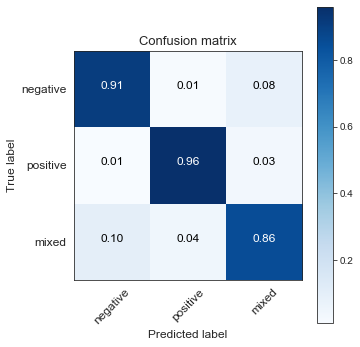

```python
def bert_predictions(data, estimator, view_cm=True,
                     normalize=True, logits=False):
    """
    Classify review sentiment using bert model.

    Params:
    -----------
    data : pandas dataframe with text and label columns (same format as training).
    estimator : The fitted fast-bert model (learner object).
    view_cm : bool, default: True
              Plot confusion matrix.
    normalize : bool, default: True
                Return normalized confusion matrix.
    logits : bool, default: False
             If True returns logits from prediction, otherwise the softmax
             probabilities are returned.

    Return probabilities database and predictions array (class with highest
    estimate).
    """
    text = data.text.tolist()
    if logits:
        preds = estimator.predict_logits(text)
    else:
        preds = estimator.predict_batch(text)

    sorted_preds = [sorted(values) for values in preds]

    temp_labels = [y[0] for y in sorted_preds[0]]
    preds_df = pd.DataFrame([[y[1] for y in x] for x in sorted_preds],
                             columns=temp_labels)

    probs_ordered = preds_df[['neg', 'pos', 'mixed']].copy()
    y_preds = np.argmax(probs_ordered.to_numpy(), axis=1)

    if view_cm:
        # transform text labels to integer inputs for confusion matrix
        if type(data['label']) is np.float64:
            y_test_numeric = data.label.values
        else:
            y_test_numeric = data['label'].map({'neg': 0, 'pos': 1, 'mixed': 2}).values

        cm = confusion_matrix(y_test_numeric, y_preds)
        plot_confusion_matrix(cm, ['negative', 'positive', 'mixed'],
                              normalize=normalize)

    return probs_ordered, y_preds

val_probas, val_preds = bert_predictions(val, multiclass_predictor)
```

## Does the Model Generalize?

```
Normalized confusion matrix
```

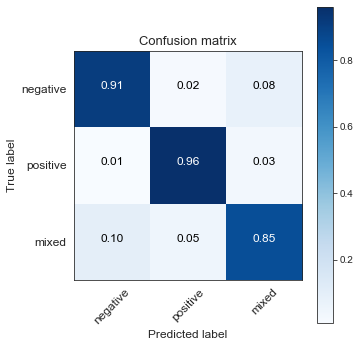

```python
train_probs, train_preds = bert_predictions(train, multiclass_predictor)
```

```python
def get_scores(labels, preds, output_dict=True):
    """Return classification report for sentiment."""
    scores = classification_report(labels, preds,
                                   target_names=['negative', 'positive', 'mixed'],
                                   output_dict=output_dict)
    return scores

val_scores = get_scores(y_val, val_preds)
val_scores
```

```
{'negative': {'precision': 0.9222826086956522,
  'recall': 0.9094319399785638,
  'f1-score': 0.9158121964382083,
  'support': 1866},
 'positive': {'precision': 0.9936198386902613,
  'recall': 0.9597674418604651,
  'f1-score': 0.9764003075649139,
  'support': 8600},
 'mixed': {'precision': 0.5778229908443541,
  'recall': 0.8554216867469879,
  'f1-score': 0.6897389192471161,
  'support': 664},
 'accuracy': 0.9451033243486073,
 'macro avg': {'precision': 0.8312418127434226,
  'recall': 0.9082070228620056,
  'f1-score': 0.860650474416746,
  'support': 11130},
 'weighted avg': {'precision': 0.9568539466741227,
  'recall': 0.9451033243486073,
  'f1-score': 0.9491405971241726,
  'support': 11130}}
```

# Error Analysis

The `eyeball validation set` consists of 500 samples. It is a subset of the validation set that is intended for manual inspection, to aid with:

> 1. Determining human-level performance, i.e. the optimal error rate to aim for/ unavoidable underfitting (bias).
> 2. Estimating noisy (incorrect) labels.
> 3. Intuition for classifier performance and errors (understand where/ how improvements can be made).

Return to Index

## Performance on the Eyeball Validation Set

```
Normalized confusion matrix
```

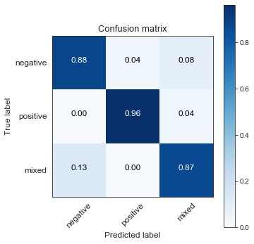

```python
eye_probas, eye_preds = bert_predictions(eye_val, multiclass_predictor)
```

```
Confusion matrix, without normalization
```

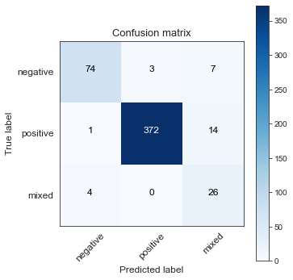

```python
# Actual number of errors
_, _ = bert_predictions(eye_val, multiclass_predictor, normalize=False)
```

```python
eyeval_df = pd.DataFrame()
eyeval_df['label'] = eye_val.label.map({'neg': 0, 'pos': 1, 'mixed': 2})
eyeval_df['text'] = eye_val.text
eyeval_df['pred'] = eye_preds
eyeval_df['neg'] = eye_probas['neg']
eyeval_df['pos'] = eye_probas['pos']
eyeval_df['mixed'] = eye_probas['mixed']

errors = [0 if eyeval_df.label[i] == eyeval_df.pred[i] else 1 for i in eyeval_df.index]

eyeval_df['error'] = errors

#eyeval_df.to_csv('data/bert_preds_eyeval3.csv')
```

```python
eyeval_df = pd.read_csv('data/bert_preds_eyeval3.csv', index_col=0)
error_analysis = eyeval_df.groupby('label')['error', 'label_error','boundary_case',
                                            'true_error', 'neg_error', 'pos_error',
                                            'mix_error'].sum()
error_analysis
```

| label | error | label_error | boundary_case | true_error | neg_error | pos_error | mix_error |
| --- | --- | --- | --- | --- | --- | --- | --- |
| 0 | 10 | 14 | 4 | 6 | 0 | 2 | 12 |
| 1 | 15 | 15 | 4 | 7 | 0 | 1 | 14 |
| 2 | 4 | 0 | 2 | 4 | 0 | 0 | 0 |

# Classifier Errors

Ten "errors" were in fact correct predictions made on incorrect labels, leaving 17 true errors.

`MISLABELED + MISPREDICTED: 9/500`

```
- All below .9 confidence, the highest being .81.
```

`CORRECTLY LABELED + MISPREDICTED: 8/500`

```
- 5/8 unambiguous (one above .9)
- 3/8 ambiguous, label would be accepted by human (two above .9)
```

`MISLABELED + CORRECTLY PREDICTED: 10/500`

```
- 60% above .9 confidence.
```

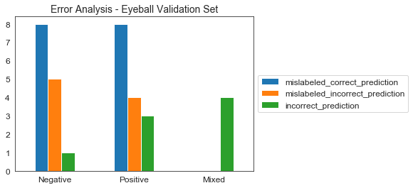

```python
# totals below were taken from above summary and also full dataset
error_analysis['mislabeled_correct_prediction'] = [8, 8, 0]
error_analysis['mislabeled_incorrect_prediction'] = [5, 4, 0]
error_analysis['incorrect_prediction'] = [1, 3, 4]

error_analysis.iloc[:, -3:].plot(kind='bar')
plt.xticks(np.arange(3), labels = ['Negative', 'Positive', 'Mixed'],
           rotation=0, fontsize=12)
plt.yticks(fontsize=12)
plt.legend(loc='center left', bbox_to_anchor=(1, 0.5), fontsize=12)
plt.title('Error Analysis - Eyeball Validation Set', fontsize=14)
plt.xlabel(None);
```

Note: The bar chart shows which class the incorrect label originally belonged to. More details below.

## Noisy Labels

`INCORRECT LABELS:`  
29/500 (**~5.8%**) labels were incorrectly labeled.

> - 26/29 (**5.2%**) are mislabeled mixed.
> - 1/29 (**0.2%**) are mislabeled negative.
> - 2/29 (**0.4%**) are mislabeled positive.

## Label Correction:

Correcting the labels in the eyeball validation set and recalculating the recall for each class, shows that the classifier is in fact performing well on the minority class and compensating for the noisy labels.

`Recalculated Recall:`

```
Neg = 6/70 errors = 8.6% = 91.4%
Pos = 7/374 errors = 1.9% = 98.1%
Mixed = 4/56 errors = 7.1% = 92.9%
```

## How Confident were Mistakes?

Looking at whether the classifier made confident mistakes or not helps to *determine how much control we have over filtering out incorrect predictions.* For instance, if all mistakes are below .8 we could make the decision to send predictions below .8 to a human for a response. Confident mistakes are impossible to filter out this way.

> - Mixed (none above .41); positive (two above .9); negative (two above .9). Therefore, 4/17 (23.5%) were confident errors.
> - The rest were less confident border-cases.

Total Error = 17/500 = 3.4%  
Confident Error = 4/500 = 0.8%  
`CONFIDENT ERRORS:`  
Two of the confident errors were ambiguous by human standards (i.e., the human judge probably used additional information (the rating) to determine the meaning of these reviews):

```
- "Usually awesome staff. Kids friendly. However if you a coffee lover. Watch out!"
- "Service!!!!"
```

For the unambiguous cases, one was mislabeled:

```
- "Half a smoothie was given to me and no straw."
```

While one was correctly labeled:

```
- "The service is on fire on another level."
```

Therefore, 2/4 (50%) of the confident errors were unambiguous (unavoidable) and can be classed as true and costly (undetectable) error. This is estimated at .4% of the entire dataset.

## Avoidable Bias (underfitting):

Human error on this dataset is approximately 0.5-1%. The classifier is therefore underfitting by 2.5% (although only **.4%** confidentally). Considering that there are ~6% noisy labels, this underfitting may be unavoidable unless the labels are corrected. It is likely that training for more epochs will not fix the current error and may even result in the classifier overfitting to the noisy labels.

# Correct Labels using Predictions

Return to Index

Because the classifier is performing well, the most confident predictions can be used to correct some of the incorrect labels.

```python
test_probs, test_preds = bert_predictions(test, multiclass_predictor, view_cm=False)

train.reset_index(inplace=True, drop=True)
val.reset_index(inplace=True, drop=True)
test.reset_index(inplace=True, drop=True)

train_concat = pd.concat([train, train_probs], axis=1)
val_concat = pd.concat([val, val_probas], axis=1)
test_concat = pd.concat([test, test_probs], axis=1)

def correct_labels(df, threshold=0.5):
    """
    Replace incorrect labels. Use probability cutoffs for a
    predicted class that conflict with current labels
    to identify labels that are likely incorrect.

    Params:
    -------
    df: pandas dataframe with sentiment class probabilities and label
        columns.
    threshold: int, probability threshold for class prediction.

    Return dataframe with corrected labels and list of indexes
    for corrected samples.
    """
    df = df.copy()
    num_incorrect = 0
    for col in ['neg','pos','mixed']:
        idx = df.index[(df[col] > threshold) & (df.label != col)]
        for i in idx:
            df['label'][i] = col
        num_incorrect = len(idx)
    print('Number of Corrected Labels: {}'.format(num_incorrect))
    print('Total Percentage Changed: {}'.format(num_incorrect/len(df)*100))
    return df, idx

# threshold was gradually decreased for confidences from .95 to .5
# After corrections were made for each threshold, changes to the validation
# labels were manually inspected. Results are presented below.

train_corrected, _ = correct_labels(train_concat, threshold=0.8)
val_corrected, idx_corrected = correct_labels(val_concat, threshold=0.8)
test_corrected, _ = correct_labels(test_concat, threshold=0.8)
```

```
Number of Corrected Labels: 3426
Total Percentage Changed: 2.3942136342988927
Number of Corrected Labels: 279
Total Percentage Changed: 2.5067385444743935
Number of Corrected Labels: 114
Total Percentage Changed: 2.3899371069182394
```

```python
# sanity check to ensure labels were changed
print('Incorrect Label:')
print('-'*80)
print(train_concat.loc[970])
print('\nCorrected:')
print('-'*80)
train_corrected.loc[970]
```

```
Incorrect Label:
--------------------------------------------------------------------------------
text     Our waitress Deolene was spectacular.
label                                       neg
neg                                 0.000129683
pos                                     0.99926
mixed                               0.000610727
Name: 970, dtype: object

Corrected:
--------------------------------------------------------------------------------
```

```
text     Our waitress Deolene was spectacular.
label                                       pos
neg                                 0.000129683
pos                                     0.99926
mixed                               0.000610727
Name: 970, dtype: object
```

## How many incorrect labels were corrected?

```python
# accuracy of corrections were manually examined in excel
# each time a new threshold was used to correct the labels
eyeball_corrections = [['.95', 119, 2, 0], ['.90', 78, 1, 1], ['.85', 42, 2, 2],
                       ['.80', 28, 3, 1], ['.75', 23, 3, 5], ['.65', 33, 1, 4],
                       ['.55', 31, 3, 1], ['.5', 23, 2, 3]]

# database of correct-incorrect comparisons and percentages for various
# thresholds
corrections = pd.DataFrame(columns= ['threshold', 'corrected', 'incorrect_amb',
                                     'incorrect_unamb'])

for i, threshold in enumerate(eyeball_corrections):
    corrections.loc[i] = threshold

# totals given for additional samples in each threshold only
corrections['non_cum_totals'] = corrections['corrected'] + \
                                corrections['incorrect_amb'] + \
                                corrections['incorrect_unamb']

corrections['cumulative_total'] = corrections['non_cum_totals'].cumsum()
corrections['cum_%'] = 100*corrections['cumulative_total']/corrections['non_cum_totals'].sum()

corrections['cum_%_correct'] = 100*(corrections.corrected.cumsum() / corrections.non_cum_totals.cumsum())
corrections['%_correct'] = (corrections.corrected / corrections.non_cum_totals)*100

corrections['%_amb'] = ((corrections.non_cum_totals - \
    (corrections.corrected + corrections.incorrect_unamb)) / corrections.non_cum_totals)*100
corrections['cum_%_amb'] = 100*(corrections.incorrect_amb.cumsum() / corrections.non_cum_totals.cumsum())
corrections['%_unamb'] = ((corrections.non_cum_totals - \
    (corrections.corrected + corrections.incorrect_amb)) / corrections.non_cum_totals)*100
corrections['cum_%_unamb'] = 100*(corrections.incorrect_unamb.cumsum() / corrections.non_cum_totals.cumsum())

corrections
```

|  | threshold | corrected | incorrect_amb | incorrect_unamb | non_cum_totals | cumulative_total | cum_% | cum_%_correct | %_correct | %_amb | cum_%_amb | %_unamb | cum_%_unamb |
| --- | --- | --- | --- | --- | --- | --- | --- | --- | --- | --- | --- | --- | --- |
| 0 | .95 | 119 | 2 | 0 | 121 | 121 | 29.4404 | 98.3471 | 98.3471 | 1.65289 | 1.65289 | 0 | 0 |
| 1 | .90 | 78 | 1 | 1 | 80 | 201 | 48.9051 | 98.01 | 97.5 | 1.25 | 1.49254 | 1.25 | 0.497512 |
| 2 | .85 | 42 | 2 | 2 | 46 | 247 | 60.0973 | 96.7611 | 91.3043 | 4.34783 | 2.02429 | 4.34783 | 1.21457 |
| 3 | .80 | 28 | 3 | 1 | 32 | 279 | 67.8832 | 95.6989 | 87.5 | 9.375 | 2.86738 | 3.125 | 1.43369 |
| 4 | .75 | 23 | 3 | 5 | 31 | 310 | 75.4258 | 93.5484 | 74.1935 | 9.67742 | 3.54839 | 16.129 | 2.90323 |
| 5 | .65 | 33 | 1 | 4 | 38 | 348 | 84.6715 | 92.8161 | 86.8421 | 2.63158 | 3.44828 | 10.5263 | 3.73563 |
| 6 | .55 | 31 | 3 | 1 | 35 | 383 | 93.1873 | 92.4282 | 88.5714 | 8.57143 | 3.91645 | 2.85714 | 3.65535 |
| 7 | .5 | 23 | 2 | 3 | 28 | 411 | 100 | 91.7275 | 82.1429 | 7.14286 | 4.13625 | 10.7143 | 4.13625 |

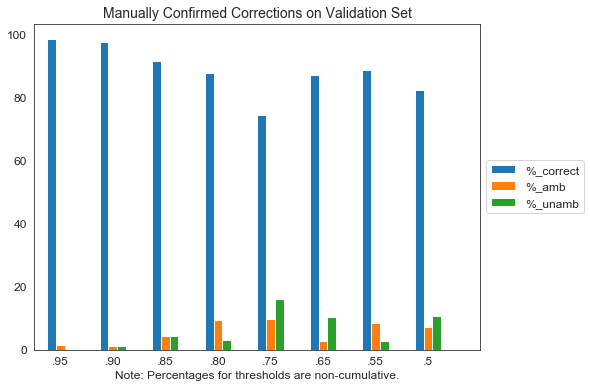

```python
corrections[['%_correct', '%_amb', '%_unamb']]\
           .plot(kind='bar', figsize=(8, 6))
plt.xticks(np.arange(9), labels = corrections.threshold, rotation=0, fontsize=12)
plt.yticks(fontsize=12)
plt.legend(loc='center left', bbox_to_anchor=(1, 0.5), fontsize=12)
plt.xlabel('Note: Percentages for thresholds are non-cumulative.', fontsize=12);
plt.title('Manually Confirmed Corrections on Validation Set', fontsize=14);
```

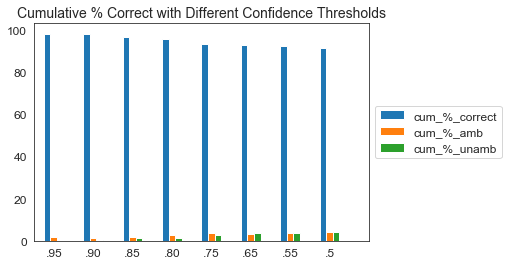

```python
corrections[['cum_%_correct', 'cum_%_amb', 'cum_%_unamb']]\
           .plot(kind='bar', figsize=(6, 4))
plt.xticks(np.arange(9), labels = corrections.threshold, rotation=0, fontsize=12)
plt.yticks(fontsize=12)
plt.legend(loc='center left', bbox_to_anchor=(1, 0.5), fontsize=12)
#plt.xlabel('Note: Percentages for thresholds are non-cumulative, except for total.', fontsize=12);
plt.title('Cumulative % Correct with Different Confidence Thresholds', fontsize=14);
```

**~95%** of the labels changed were correct using a probability cutoff of .8.

**~92%** were correct using a cutoff of .55.

## Class Distributions after Correction

A probability cutoff of .8 was used going forward for correction. This changed approximately 2.5% of the labels (mostly to mixed).

```python
train.label.value_counts(normalize=True)
```

```
pos      0.772620
neg      0.167651
mixed    0.059730
Name: label, dtype: float64
```

```python
# all corrections were for the mixed class. Most were incorrect positive labels
# After correction mixed were closer to 8%
train_corrected.label.value_counts(normalize=True)
```

```
pos      0.755400
neg      0.164625
mixed    0.079975
Name: label, dtype: float64
```

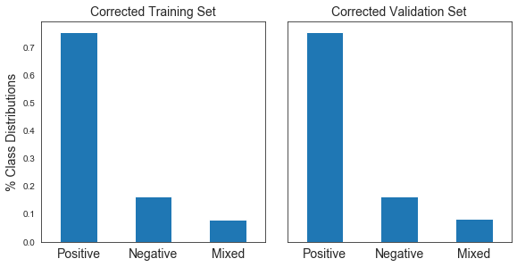

```python
fig, ax = plt.subplots(ncols=2, sharey=True, figsize=(8,4), constrained_layout=True)
fig.tight_layout()

train_corrected.label.map({'neg': 0, 'pos': 1, 'mixed': 2})\
                     .value_counts(normalize=True)\
                     .plot(kind='bar', ax=ax[0])

ax[0].set_xticklabels(['Positive', 'Negative', 'Mixed'], rotation=0, fontsize=14)
ax[0].set_title('Corrected Training Set', fontsize=14)
ax[0].set_ylabel('% Class Distributions', fontsize=14)

val_corrected.label.map({'neg': 0, 'pos': 1, 'mixed': 2})\
                   .value_counts(normalize=True)\
                   .plot(kind='bar', ax=ax[1])

ax[1].set_xticklabels(['Positive', 'Negative', 'Mixed'], rotation=0, fontsize=14)
ax[1].set_title('Corrected Validation Set', fontsize=14);
```

# Predictions on Corrected Dataset

Return to Index

Predictions were made for the corrected dataset using the classifier trained on the uncorrected data.

Because the correction removes the models uncertainty, retraining on this dataset will likely bias the results (the probabilities may be over confident since not *all* incorrect labels were corrected - only those already identified by the model).

However, correcting ~2.5% of the labels will give us a more accurate idea of the classifiers performance and will help calibration of the probabilities as well.

```
Normalized confusion matrix
```

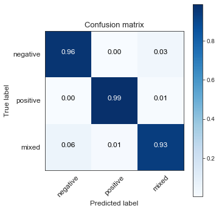

```python
val_probs_corrected, val_preds_corrected = bert_predictions(val_corrected, multiclass_predictor)
```

```python
# Get logits for calibration
val_logits, val_logit_preds = bert_predictions(val_corrected, multiclass_predictor,
                                               logits=True, view_cm=False)

assert val_preds.all() == val_logit_preds.all()
(val_preds == val_logit_preds).all()
```

```
True
```

# Final Results - Test Set

```
Normalized confusion matrix
```

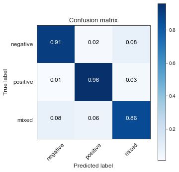

```python
# bert trained on uncorrected labels + original test set

# These results contain ~6% label errors, mostly mixed
# Performance is consistent with predictions on train and validation sets.
test_probs, test_preds = bert_predictions(test, multiclass_predictor)
```

```
Normalized confusion matrix
```

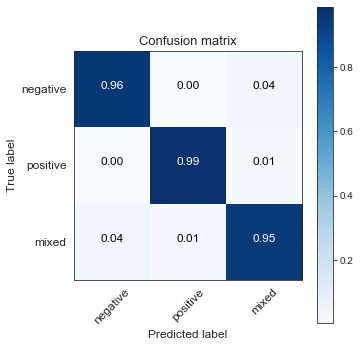

```python
# bert trained on uncorrected labels + corrected test set

test_probs_corrected, test_preds_corrected = bert_predictions(test_corrected, multiclass_predictor)
```

# Calibration

Return to Index

Probabilistic classifiers output a probability distribution over target classes, rather than just a prediction. The value of this distribution is that it represents the amount of uncertainty in those predictions. However, the probabilities outputted do not always accurately represent the amount of uncertainty - sometimes probabilities are over- or under-confident.

**["Calibration - the idea that a model's predicted probabilities of outcomes reflect true probabilities of those outcomes - formalizes this notion"](https://arxiv.org/abs/1904.01685)**

> **NOTE:** Custom methods were created for this multiclass calibration. See: `calibration_methods.py` and `calibration_functions.py`. Methods from the [Netcal](https://fabiankueppers.github.io/calibration-framework/build/html/index.html) and [Calibration](https://github.com/markus93/NN_calibration) libraries were used directly or adapted. Certain methods from this repo were also adapted [NN Calibration](https://github.com/markus93/NN_calibration).

# Diagnosing Miscalibration

## Probability Distributions

The distribution of the probabilities shows that most tended towards 0 and 1, especially for the positive and negative classes. This may be an indication of over-confident estimates.

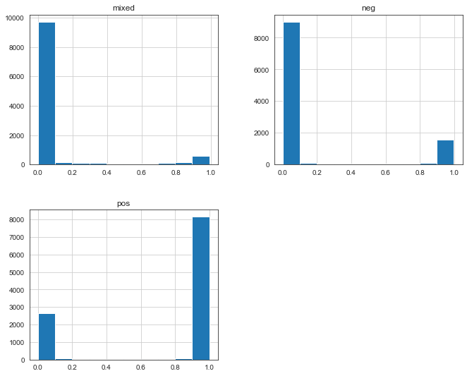

```python
import calibration_methods
from calibration_methods import TemperatureScaling, DirichletScaling, Uncalibrated, Isotronic

pd.DataFrame(val_probs_corrected).hist(figsize=(11,9));
```

```
Normalized confusion matrix
```

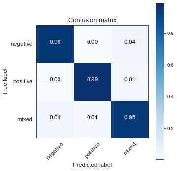

```python
# As expected, logits do not change overall predictions.
test_logits_corrected, _ = bert_predictions(test_corrected, multiclass_predictor,
                                            logits=True, view_cm=True)
```

```python
# create numpy arrays for the estimated probabilities and logits
val_probs_arr = np.array(val_probs_corrected)
val_logits_arr = np.array(val_logits)
y_val_correct = np.array(val_corrected['label'].map({'neg':0, 'pos':1, 'mixed':2}))

test_probs_arr = np.array(test_probs_corrected)
test_logits_arr = np.array(test_logits_corrected)
y_test_correct = np.array(test_corrected['label'].map({'neg':0, 'pos':1, 'mixed':2}))

val_probs_arr
```

```
array([[1.32257454e-04, 9.99390006e-01, 4.77686583e-04],
       [1.77965267e-04, 9.98853803e-01, 9.68222332e-04],
       [8.55866075e-03, 9.29258943e-01, 6.21824376e-02],
       ...,
       [1.22622092e-04, 9.99600947e-01, 2.76398205e-04],
       [4.98309731e-04, 9.98035729e-01, 1.46597193e-03],
       [9.96568441e-01, 1.93872896e-03, 1.49289286e-03]])
```

# Evaluation Metrics

[Strictly proper scoring rules](https://en.wikipedia.org/wiki/Scoring_rule), as well as multiple [calibration error metrics](https://arxiv.org/abs/1904.01685) were used to evaluate calibration (in addition to the reliability diagrams and histograms).

`CALIBRATION ERROR:`  
**Expected Calibration Error:** Discretize the probability interval into a fixed number of bins and assign predicted probabilities to each bin. The calibration error is the difference between the number of correct probabilities (accuracy) and the mean of all probabilities (confidence) for each bin.

**Classwise ECE:** The ECE calculated for each class.

**Adaptive ECE:** The Adaptive ECE focuses on those bins where predictions are made rather than weighing all bins equally. This metric spaces the bin intervals in such a way that each contains an equal number of predictions.

`PROPER LOSSES:`  
**Brier Score:** "The Brier score measures the mean squared difference between (1) the predicted probability assigned to the possible outcomes for item i, and (2) the actual outcome. Therefore, the lower the Brier score is for a set of predictions, the better the predictions are calibrated." [sklearn metrics](https://scikit-learn.org/stable/modules/generated/sklearn.metrics.brier_score_loss.html)

**Negative Log-Likelihood:** The NLL also average the error on every single instance to calculate the calibration error.

`PROPORTION CORRECT/ INCORRECT:`  
**F1-Macro weighted:** The weighted average of the precision and recall. Calculate metrics for each label, and find their unweighted mean.

`RELIABILITY DIAGRAMS:`  
When average confidence closely matches accuracy, [the classifier is well calibrated](https://arxiv.org/abs/1706.04599). This can be seen in the reliability diagrams below. In the histrogram it is the distance between the grey and black lines, and for the binned confidence any deviation from the perfect diagonal represents miscalibration (visually represents ECE).

A combination of reliability diagrams, proper scoring and calibration error metrics give a well rounded view on miscalibration and improvements made.

# Uncalibrated Results

```
Uncalibrated - Calibration Metrics
--------------------------------------------------
ECE:  0.0137
Classwise/ Static ECE:  0.0113
Adaptive ECE:  0.019
Brier Multi Score:  0.0287
f1 - macro:  0.9503
Negative Log-Likelihood:  0.0557


Confidence-Reliability Visual Evaluation
------------------------------------------------------------
```

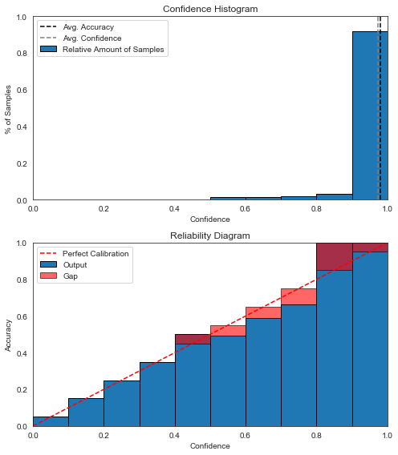

```
Classwise-Reliability Visual Evaluation
------------------------------------------------------------
```

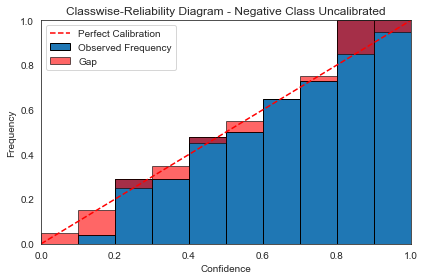

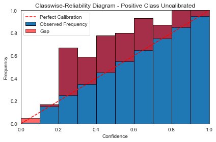

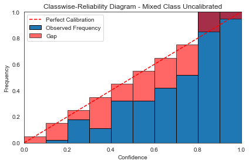

```python
uncalibrated = Uncalibrated(test_probs_arr, y_test_correct)

uncal_df = uncalibrated.evaluation_metrics()
print('\n')
uncalibrated.diagrams(classwise=True)
```

While the overall confidence-reliability for the model shows very little calibration error, the [classwise reliability diagrams](https://arxiv.org/abs/1910.12656) show that the `positive` and `mixed` classes are uncalibrated.

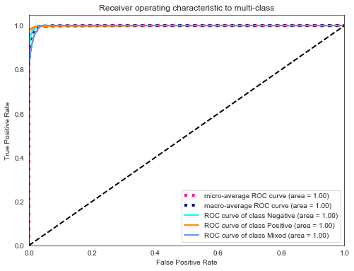

```python
# The multiclass ROC curve shows very good separation between the classes
# before calibration
multiclass_roc_curve(test_probs_arr, y_test_correct)
```

# Temperature Scaling

An extension of Platt scaling, this method essentially maximizes the entropy of the ouput probability subject to certain constraints (it "softens" the softmax function applied to the logits, but does not change the maximum of the function. Class prediction therefore stays the same and the accuracy is unchanged). In other words, the probabilities are scaled by reducing overconfidence (increasing entropy) without changing predictions. This ensures that the probability estimates better approximate true probabilities and prevent overfitting via minimization of error, in this case NLL (negative log likelihood).

This is a post-processing method that does not change the learnt parameters/ weights of the model, but rather optimizes temperature (T) with respect to NLL on the validation logits.

```python
val_logits_corr
```

```
array([[-3.73809862,  5.19205141, -2.4538939 ],
       [-3.81019235,  4.8225832 , -2.1163187 ],
       [-2.68028021,  2.00716376, -0.69715083],
       ...,
       [-3.53345156,  5.47255325, -2.72071576],
       [-3.27503014,  4.32729244, -2.1959784 ],
       [ 4.41873026, -1.82355499, -2.08487153]])
```

```
Temperature Scaling - Calibration Metrics
--------------------------------------------------
ECE:  0.0098
Classwise/ Static ECE:  0.0083
Adaptive ECE:  0.0154
Brier Multi Score:  0.0289
f1 - macro:  0.9485
Negative Log-Likelihood:  0.0575


Confidence-Reliability Visual Evaluation
------------------------------------------------------------
```

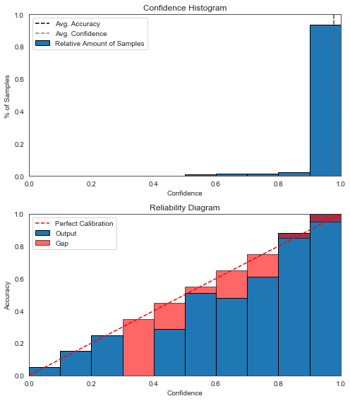

```
Classwise-Reliability Visual Evaluation
------------------------------------------------------------
```

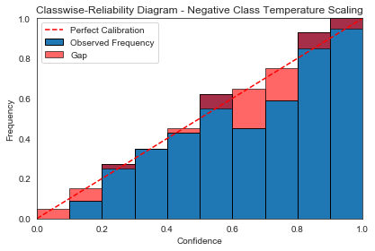

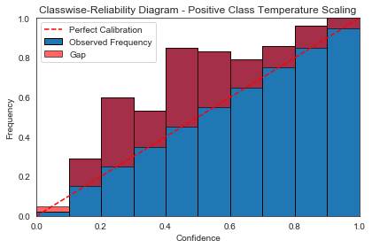

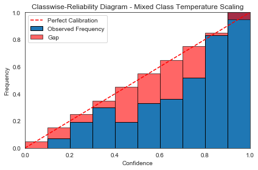

```
Normalized confusion matrix
```

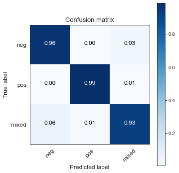

```python
temp = TemperatureScaling()
temp.fit(val_logits_arr, y_val_correct)
temp_probs = temp.transform(val_logits_arr)

temp_df = temp.evaluation_metrics()
print('\n')
temp.diagrams(classwise=True)
temp.get_confusion_matrix(classes = ['neg', 'pos', 'mixed'])
```

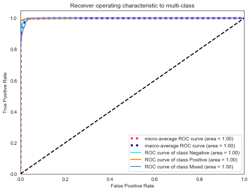

```python
multiclass_roc_curve(temp_probs, y_val_correct)
```

# Dirichlet Scaling

Temperature scaling only has a single tunable parameter and therefore cannot learn to act differently on different classes. Dirichlet scaling is applies better to multiclass models, able to calibrate each class more effectively.

To apply Dirichlet scaling the log probabilities are provided as inputs to a `Multinomial Logistic Regression` model. The model is fitted on the validation probabilties and the test probabilities are used for evaluation.

```
Dirichlet Scaling - Calibration Metrics
--------------------------------------------------
ECE:  0.0072
Classwise/ Static ECE:  0.005
Adaptive ECE:  0.0079
Brier Multi Score:  0.0251
f1 - macro:  0.9504
Negative Log-Likelihood:  0.0451


Confidence-Reliability Visual Evaluation
------------------------------------------------------------
```

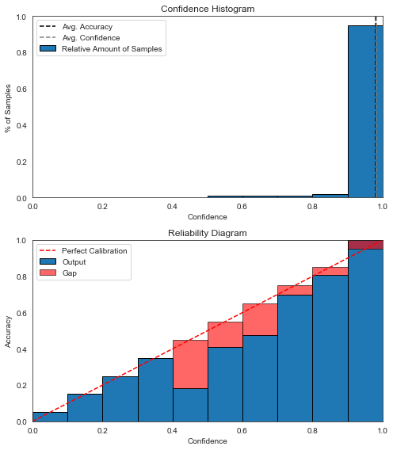

```
Classwise-Reliability Visual Evaluation
------------------------------------------------------------
```

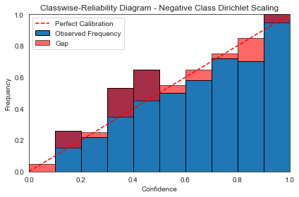

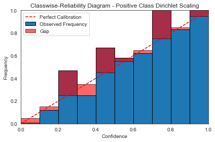

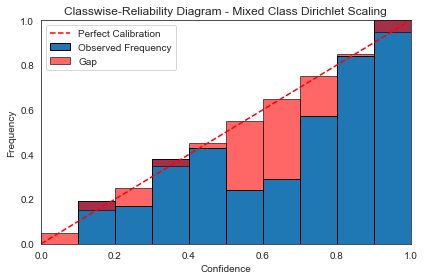

```
Normalized confusion matrix
```

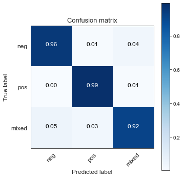

```python
dirichlet = DirichletScaling(y_test_correct)
dirichlet.fit(val_probs_arr, y_val_correct)
dir_probs = dirichlet.transform(test_probs_arr)

dir_df = dirichlet.evaluation_metrics()
print('\n')
dirichlet.diagrams(classwise=True)
dirichlet.get_confusion_matrix(classes = ['neg', 'pos', 'mixed'])
```

Compared with Temperature Scaling, the classwise reliability diagrams show improved classwise calibration with Dirichlet Scaling. However, there is reduced predictive accuracy of the minority mixed class.

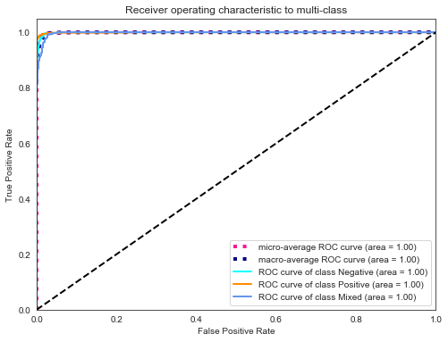

```python
# The class separation prediction remain similar.
multiclass_roc_curve(dir_probs, y_test_correct)
```

# Isotronic Scaling

Isotonic Regression is a more powerful calibration method that can correct any monotonic distortion.

```
Isotronic Regression - Calibration Metrics
--------------------------------------------------
ECE:  0.0009
Classwise/ Static ECE:  0.0
Adaptive ECE:  0.0069
Brier Multi Score:  0.024
f1 - macro:  0.9569
Negative Log-Likelihood:  0.0448


Confidence-Reliability Visual Evaluation
------------------------------------------------------------
```

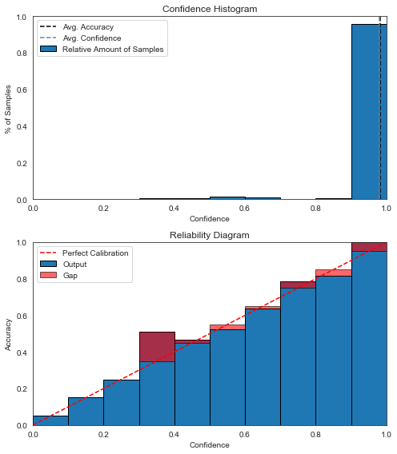

```
Classwise-Reliability Visual Evaluation
------------------------------------------------------------
```

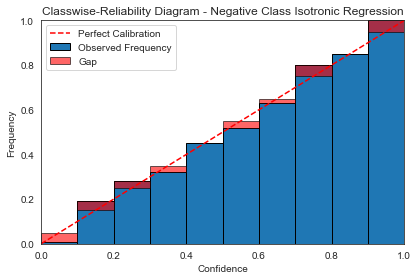

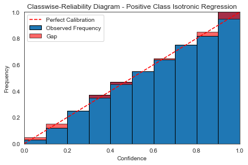

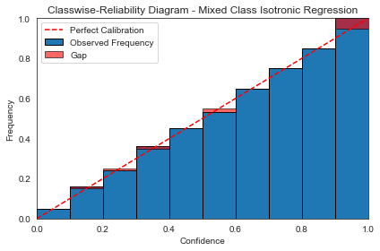

```
Normalized confusion matrix
```

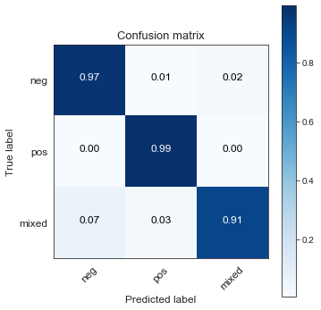

```python
iso = Isotronic(independent_probabilities=True)
iso_probs = iso.fit_transform(val_probs_arr, y_val_correct)

iso_df = iso.evaluation_metrics()
print('\n')
iso.diagrams(classwise=True)
iso.get_confusion_matrix(classes = ['neg', 'pos', 'mixed'])
```

Isotronic binning results in almost perfect calibration for each class. However, the predictive accuracy for the minority class is also the most reduced.

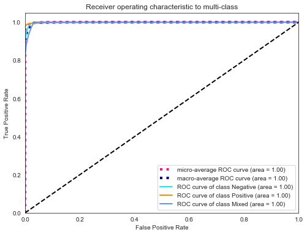

```python
multiclass_roc_curve(iso_probs, y_val_correct)
```

## Comparing Methods

```python
calibration = pd.concat([uncal_df, temp_df, dir_df, iso_df])
calibration['method'] = ['Uncalibrated', 'TempScaling', 'Dirichlet', 'Isotronic']
calibration
```

|  | ECE | Classwise ECE | Adaptive ECE | Brier | Neg Log-Likelihood | F1-Macro | method |
| --- | --- | --- | --- | --- | --- | --- | --- |
| 0 | 0.013671 | 1.129069e-02 | 0.018970 | 0.028655 | 0.055705 | 0.950331 | Uncalibrated |
| 0 | 0.009786 | 8.320712e-03 | 0.015426 | 0.028946 | 0.057549 | 0.948478 | TempScaling |
| 0 | 0.007231 | 4.999860e-03 | 0.007907 | 0.025096 | 0.045101 | 0.950370 | Dirichlet |
| 0 | 0.000881 | 1.295094e-18 | 0.006942 | 0.023990 | 0.044822 | 0.956947 | Isotronic |

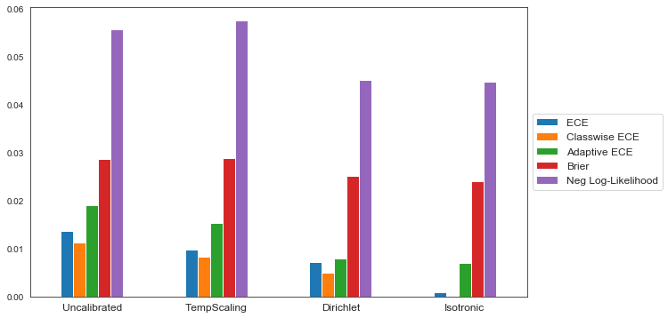

```python
calibration.iloc[:, :-2].plot(kind='bar', figsize=(10, 6))
plt.xticks(np.arange(len(calibration)), labels = calibration.method,
           rotation=0, fontsize=12)
plt.legend(loc='center left', bbox_to_anchor=(1, 0.5), fontsize=12);
```

Certain calibration methods appear to calibrate the probabilities at the expense of predictive performance for the minority class. While Isotronic Binning and Dirichlet Scaling both reduce calibration error substantially, by balancing the classes before calibration `mixed sentiment` accuracy can potentially be maintained. These [techniques](https://datascience.stackexchange.com/questions/65908/are-calibrated-probabilities-always-more-reliable) will be explored and added to the notebook shortly.

# Conclusion

The fast-bert model performed better than the XGBoost model, and required less preprocessing. The fast-bert framework was added to the AWS ecosystem and the classifier was made available as an endpoint. After an evaluation period, it will be decided whether the probabilities should be calibrated, and if so, the prefered method will be added as a post-processing function.

Return to Index